# 03: Spectral Unmixing and Transformation

← Prev: QC Next: Gating →

```r
library(flowCore)
library(flowWorkspace)
library(flowSpecs)
library(tidyverse)
```

```r
ff_raw <- readRDS("data/processed/PBMC_ff_qc.rds")
data(specMat)
```

## Why transformation is necessary

Raw spectral flow data has two properties that make it difficult to work with directly:

1. **The range is enormous.** Highly expressed markers can have 100× more signal than dimly expressed ones. On a linear scale, dim populations collapse into an unresolvable cluster near zero.
2. **Negative values exist.** After spectral unmixing, cells with no true expression of a marker can have slightly negative values due to spectral spillover and detector noise. Standard log transformation breaks on negatives.

**Arcsinh** is the standard transformation for spectral flow. The `b` parameter (`b = 1/cofactor`) controls the linear-to-log transition. Apply it only to fluorochrome channels — scatter parameters (FSC, SSC) are already on a meaningful linear scale.

## Checking `$PnE`

Run this on every new dataset before doing anything else:

```r
keyword(ff_raw, paste0("$P", 1:6, "E"))
```

```
## $`$P1E`
## [1] "0,0"
##
## $`$P2E`
## [1] "0,0"
##
## $`$P3E`
## [1] "0,0"
##
## $`$P4E`
## [1] "0,0"
##
## $`$P5E`
## [1] "0,0"
##
## $`$P6E`
## [1] "0,0"
```

All channels are `"0,0"` — untransformed linear values. This is the expected result for Aurora data and confirms we need to apply transformation ourselves. If you see anything other than `"0,0"` for fluorescence channels, a transformation was already applied at export and applying another would be wrong.

## Spectral unmixing

Before we can transform fluorochrome channels, we need to create them. Right now the data is organised by detector (V1-A, B1-A, R1-A, etc.). Spectral unmixing decomposes each cell’s full detector spectrum into per-fluorochrome contributions using the known spectral signature of each fluorochrome.

In most labs this step happens in SpectroFlo, which exports unmixed FCS files for loading into R. Here we demonstrate it in R using `specUnmix()` from the `flowSpecs` package and a pre-computed unmixing matrix.

```r
cat("Fluorochromes:", rownames(specMat), "\n")
```

```
## Fluorochromes: AF647_IgM AF700_CD4 APCCy7_CD19 BV605_CD14 BV650_CD56 BV711_CD11c BV785_CD8a FITC_CD41b PB_CD3 PE_X PECy7_CD45RA PO_DCM Autofluo
```

```r
cat("Detector channels:", ncol(specMat), "\n")
```

```
## Detector channels: 42
```

Apply the unmixing matrix to the QC-cleaned data:

```r
ff_unmixed <- specUnmix(ff_raw, specMat)
colnames(ff_unmixed)
```

```
##  [1] "Time"         "SSC-H"        "SSC-A"        "FSC-H"        "FSC-A"
##  [6] "Original_ID"  "AF647_IgM"    "AF700_CD4"    "APCCy7_CD19"  "BV605_CD14"
## [11] "BV650_CD56"   "BV711_CD11c"  "BV785_CD8a"   "FITC_CD41b"   "PB_CD3"
## [16] "PE_X"         "PECy7_CD45RA" "PO_DCM"       "Autofluo"
```

The 42 detector channels have been replaced by 13 fluorochrome channels plus scatter. Rename them to put the marker first:

```r
channel_map <- c(
  "AF647_IgM"    = "IgM_AF647",
  "AF700_CD4"    = "CD4_AF700",
  "APCCy7_CD19"  = "CD19_APCCy7",
  "BV605_CD14"   = "CD14_BV605",
  "BV650_CD56"   = "CD56_BV650",
  "BV711_CD11c"  = "CD11c_BV711",
  "BV785_CD8a"   = "CD8a_BV785",
  "FITC_CD41b"   = "CD41b_FITC",
  "PB_CD3"       = "CD3_PB",
  "PE_X"         = "PE_X",
  "PECy7_CD45RA" = "CD45RA_PECy7",
  "PO_DCM"       = "Viability",
  "Autofluo"     = "Autofluo"
)
cn <- colnames(ff_unmixed)
colnames(ff_unmixed) <- ifelse(cn %in% names(channel_map), channel_map[cn], cn)
colnames(ff_unmixed)
```

```
##  [1] "Time"         "SSC-H"        "SSC-A"        "FSC-H"        "FSC-A"
##  [6] "Original_ID"  "IgM_AF647"    "CD4_AF700"    "CD19_APCCy7"  "CD14_BV605"
## [11] "CD56_BV650"   "CD11c_BV711"  "CD8a_BV785"   "CD41b_FITC"   "CD3_PB"
## [16] "PE_X"         "CD45RA_PECy7" "Viability"    "Autofluo"
```

> **On your own SpectroFlo-unmixed data:** Your FCS files already have fluorochrome channels — skip `specUnmix()` entirely. Just rename channels from fluorochrome notation (e.g., `BV421-A`) to marker notation (e.g., `CD3_BV421`) using the same approach.

## Arcsinh transformation

Check the raw value ranges to confirm that negative values are present and transformation is needed:

```r
fluor_channels <- c("CD3_PB", "CD4_AF700", "CD8a_BV785",
                    "CD14_BV605", "CD19_APCCy7", "CD56_BV650")

for (ch in fluor_channels) {
  vals <- exprs(ff_unmixed)[, ch]
  cat(ch, ": range", round(range(vals), 0),
      "| negatives:", sum(vals < 0), "\n")
}
```

```
## CD3_PB : range -72341 102187 | negatives: 717
## CD4_AF700 : range -6012 78997 | negatives: 1466
## CD8a_BV785 : range -15399 555639 | negatives: 572
## CD14_BV605 : range -27357 256576 | negatives: 977
## CD19_APCCy7 : range -18454 536129 | negatives: 3630
## CD56_BV650 : range -21105 329296 | negatives: 1528
```

There are substantial negative values from spectral unmixing. A cofactor of 3000 is appropriate for this dataset’s value range — it places the linear-to-log transition where the negative lobe and positive populations are both visible. Apply arcsinh to all fluorochrome channels but not scatter or Time:

```r
fluor_all  <- setdiff(colnames(ff_unmixed),
                      c("Time", "SSC-H", "SSC-A", "FSC-H", "FSC-A"))
asinhTrans <- arcsinhTransform(transformationId = "arcsinh", a = 0, b = 1/3000, c = 0)
transList  <- transformList(fluor_all, asinhTrans)
ff_transformed <- transform(ff_unmixed, transList)
```

The clearest demonstration of what transformation does: plot CD4 vs CD8 before and after. Before, all signal is compressed into a tiny corner and populations are invisible. After, three populations separate cleanly — CD4+ T helper cells, CD8+ cytotoxic T cells, and double-negative non-T cells.

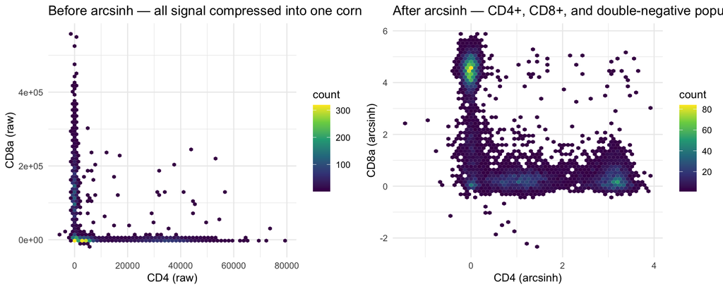

```r
df_before <- as.data.frame(exprs(ff_unmixed)[, c("CD4_AF700", "CD8a_BV785")])
df_after  <- as.data.frame(exprs(ff_transformed)[, c("CD4_AF700", "CD8a_BV785")])

p1 <- ggplot(df_before, aes(x = CD4_AF700, y = CD8a_BV785)) +
  geom_hex(bins = 60) +
  scale_fill_viridis_c() +
  theme_minimal(base_size = 11) +
  labs(title = "Before arcsinh — all signal compressed into one corner",
       x = "CD4 (raw)", y = "CD8a (raw)")

p2 <- ggplot(df_after, aes(x = CD4_AF700, y = CD8a_BV785)) +
  geom_hex(bins = 60) +
  scale_fill_viridis_c() +
  theme_minimal(base_size = 11) +
  labs(title = "After arcsinh — CD4+, CD8+, and double-negative populations visible",
       x = "CD4 (arcsinh)", y = "CD8a (arcsinh)")

gridExtra::grid.arrange(p1, p2, ncol = 2)
```

## Save

```r
fs_transformed <- flowSet(list(PBMC = ff_transformed))
gs_out <- GatingSet(fs_transformed)
unlink("data/processed/PBMC_gs_transformed", recursive = TRUE)
save_gs(gs_out, path = "data/processed/PBMC_gs_transformed")
```

```
## Done
## To reload it, use 'load_gs' function
```

```r
cat("Transformed GatingSet saved\n")
```

```
## Transformed GatingSet saved
```

> **Cofactor for your own Aurora data:** The standard cofactor for SpectroFlo-unmixed spectral flow data is 150, not 3000. The difference is because SpectroFlo exports on a different numerical scale than R-based unmixing. Always check the range of your unmixed values and adjust the cofactor accordingly — too low and the negative lobe is over-compressed, too high and positive populations smear together.

← Prev: QC Next: Gating →